# Predicción de Retornos Financieros con Machine Learning

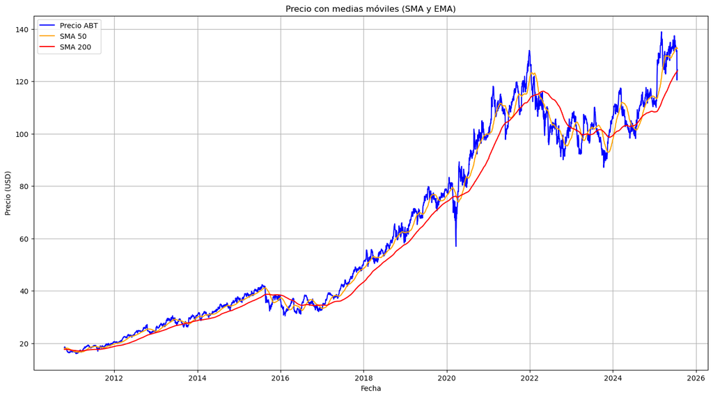

```python
plt.figure(figsize=(17,9))
plt.plot(abt["Date"], abt["ABT"], label="Precio ABT", color="blue")
plt.plot(abt["Date"], abt["SMA_50"], label="SMA 50", color="orange")
plt.plot(abt["Date"], abt["SMA_200"], label="SMA 200", color="red")
plt.title("Precio con medias móviles (SMA y EMA)")
plt.xlabel("Fecha")
plt.ylabel("Precio (USD)")
plt.legend()
plt.grid()
plt.show()

## ==================================
# Análisis media móviles (SMA y EMA)
## ==================================
#* El precio de Abbott (ABT) muestra una clara tendencia alcista de largo plazo, pasando de valores cercanos a 20 USD en 2010 a más de 130 USD en 2025.
#* La SMA 50 (línea naranja) reacciona con mayor rapidez a los cambios de tendencia, mientras que la SMA 200 (línea roja) actúa como un indicador más estable, reflejando la tendencia principal.
#* Se observan cruces de medias móviles: cuando la SMA 50 cruza por encima de la SMA 200 (golden cross), se anticipan fases de crecimiento; cuando ocurre lo contrario (death cross), se presentan caídas o correcciones.

# El uso combinado de SMA 50 y SMA 200 permite identificar momentos clave de compra/venta y validar la solidez de una tendencia.
# En el caso de Abbott, la tendencia alcista de largo plazo se mantiene, pero el análisis de los cruces de medias móviles resulta esencial para gestionar riesgos en periodos de alta volatilidad.
```

#### Grafico Análisis RSI (Relative Strength Index)

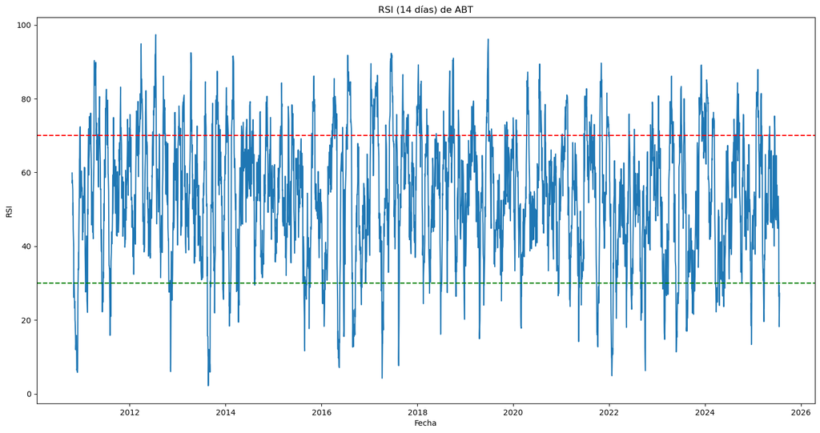

```python
plt.figure(figsize=(18,9))
plt.plot(abt["Date"], abt["RSI_14"])
plt.axhline(70, color="red", linestyle="--")
plt.axhline(30, color="green", linestyle="--")
plt.title("RSI (14 días) de ABT")
plt.xlabel("Fecha")
plt.ylabel("RSI")
plt.show()

## ==================================
# Análisis RSI
## ==================================
#* El RSI oscila frecuentemente entre los valores de 30 y 70, lo que indica que la acción suele mantenerse en una zona neutral gran parte del tiempo.
#* Se identifican episodios en los que el RSI supera 70 (sobrecompra) y cae por debajo de 30 (sobreventa), lo que marca señales potenciales de corrección o rebote.
#* La volatilidad en el RSI refleja que Abbott ha tenido múltiples fases de presión compradora y vendedora a lo largo del periodo analizado.

#* El RSI es un indicador esencial para analizar momentos de sobrecompra y sobreventa en Abbott.
#* Confirma la importancia de usarlo como complemento a otros indicadores (medias móviles, volatilidad, retornos acumulados), ya que su sensibilidad puede generar falsos positivos.
#* Su incorporación al dataset enriquece el modelo predictivo porque añade una perspectiva de momentum en el corto plazo.
```

#### Análisis de Tendencia con el Indicador MACD

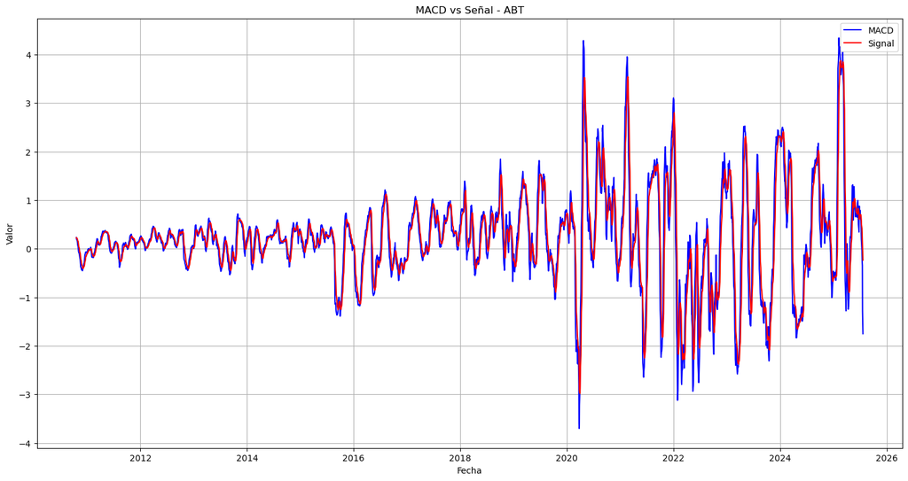

```python
plt.figure(figsize=(18,9))
plt.plot(abt["Date"], abt["MACD"], label="MACD", color="blue")
plt.plot(abt["Date"], abt["Signal"], label="Signal", color="red")
plt.title("MACD vs Señal - ABT")
plt.xlabel("Fecha")
plt.ylabel("Valor")
plt.legend()
plt.grid()
plt.show()

## ==================================
# Análisis MACD
## ==================================

#* La línea MACD (azul) oscila alrededor de 0, reflejando los cambios de tendencia en el precio de ABT.
#* La línea de señal (roja) suaviza el MACD y sirve como referencia para detectar cruces.
#* Se identifican varios episodios en los que la línea azul (MACD) cruza hacia arriba la línea roja (Señal), lo que suele asociarse con señales de compra.
#* En cambio, los cruces hacia abajo (MACD por debajo de Señal) son frecuentes en períodos de correcciones o caídas, indicando posibles ventas.
#* Los movimientos más amplios y volátiles se concentran en años de crisis o alta volatilidad (ej. 2020).

#* El MACD de ABT confirma que el activo presenta fases claras de impulso alcista y bajista, siendo un indicador valioso para estrategias de entrada y salida en el mercado.
#* Su utilidad principal radica en reforzar la detección de cambios de tendencia junto con otros indicadores (ej. RSI y medias móviles).
#* Para un modelo predictivo, el MACD aporta información complementaria sobre la fuerza y dirección de la tendencia, aumentando la robustez del análisis técnico.
```

#### Gráfico de Bandas de Bollinger (Volatilidad y Tendencia)

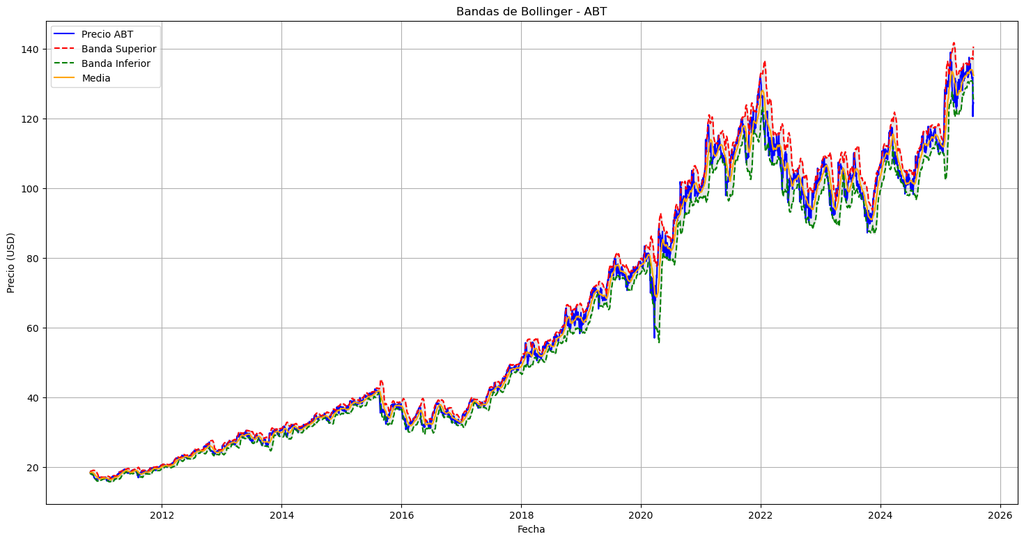

```python
plt.figure(figsize=(18,9))
plt.plot(abt["Date"], abt["ABT"], label="Precio ABT", color="blue")
plt.plot(abt["Date"], abt["BB_sup"], label="Banda Superior", color="red", linestyle="--")
plt.plot(abt["Date"], abt["BB_inf"], label="Banda Inferior", color="green", linestyle="--")
plt.plot(abt["Date"], abt["BB_medio"], label="Media", color="orange")
plt.fill_between(abt["Date"], abt["BB_inf"], abt["BB_sup"], color="gray", alpha=0.2)
plt.title("Bandas de Bollinger - ABT")
plt.xlabel("Fecha")
plt.ylabel("Precio (USD)")
plt.legend()
plt.grid()
plt.show()

## ==================================
# Análisis Bandas de Bollinger
## ==================================

#* El precio de ABT (azul) se mantiene en la mayoría del tiempo dentro de las bandas superior e inferior, lo cual refleja que las Bandas de Bollinger funcionan como un rango natural de volatilidad.
#* En los periodos de 2020 y 2022 se observan episodios donde el precio toca la banda inferior, asociados a caídas bruscas.
#* En las fases alcistas (2017-2019 y 2020-2021) el precio se acerca con frecuencia a la banda superior, indicando presión compradora.
#* La banda media (línea naranja, SMA20) actúa como nivel de soporte/resistencia dinámico.

#* Las Bandas de Bollinger son un indicador clave para complementar el análisis de volatilidad y tendencias.
#* En el caso de Abbott (ABT), muestran un activo con fases claras de sobrecompra/sobreventa, pero en general dentro de un marco de crecimiento sostenido.
#* Este indicador es útil para modelos predictivos porque captura la dinámica de volatilidad, lo que permite anticipar posibles rompimientos o consolidaciones.
```

```python
# Exportamos el data para BI
abt.to_csv("data_snp_paraBI.csv", index=False)
```

## Verificación de variables categóricas y numéricas

En este paso se revisa el tipo de variables dentro del dataset con el fin de identificar cuáles requieren un tratamiento adicional antes de aplicar algoritmos de Machine Learning.

```python
variables_categoricas = abt.select_dtypes(include=["object"]).columns
variables_categoricas

## =========================
# Resultado
## =========================
# No se encontraron variables categóricas.
```

```
Index([], dtype='object')
```

```python
variables_numericas = abt.select_dtypes(include=np.number)
variables_numericas

## =========================
# Resultado
## =========================
# Todas las columnas son numéricas, principalmente de tipo float64.
```

|  | ABT | lag_1 | lag_5 | lag_15 | lag_25 | lag_30 | lag_60 | lag_90 | EMA_20 | SMA_10 | ... | retorno_200d | volatilidad_20 | momentum_10 | BB_medio | BB_sup | BB_inf | RSI_14 | MACD | Signal | target_retorno_20d |
| --- | --- | --- | --- | --- | --- | --- | --- | --- | --- | --- | --- | --- | --- | --- | --- | --- | --- | --- | --- | --- | --- |
| 201 | 18.404198 | 18.562187 | 18.671030 | 18.277241 | 17.988234 | 17.566902 | 17.156019 | 16.328861 | 18.400116 | 18.559150 | ... | 0.003542 | 0.005749 | 0.004302 | 18.383547 | 18.835994 | 17.890766 | 59.854173 | 0.229146 | 0.224026 | -0.088135 |
| 202 | 18.551661 | 18.404198 | 18.681551 | 18.190193 | 17.970816 | 17.789755 | 17.138607 | 16.618666 | 18.414548 | 18.554784 | ... | 0.003105 | 0.006815 | -0.002367 | 18.398600 | 18.837360 | 17.929735 | 57.054669 | 0.201837 | 0.225050 | -0.098789 |
| 203 | 18.453346 | 18.551661 | 18.667509 | 18.308571 | 17.981258 | 17.946447 | 17.055048 | 16.832567 | 18.418243 | 18.579093 | ... | 0.005558 | 0.007094 | 0.013277 | 18.427816 | 18.808635 | 17.988566 | 57.862689 | 0.189904 | 0.220407 | -0.098174 |
| 204 | 18.435793 | 18.453346 | 18.843058 | 18.284199 | 18.197149 | 17.915104 | 17.089859 | 16.777365 | 18.419915 | 18.585560 | ... | -0.007989 | 0.006981 | 0.003517 | 18.446198 | 18.804919 | 18.050714 | 55.221294 | 0.170548 | 0.214307 | -0.100171 |
| 205 | 18.498991 | 18.435793 | 18.562187 | 18.482674 | 18.158850 | 17.901178 | 17.351011 | 16.825665 | 18.427446 | 18.590273 | ... | -0.013973 | 0.007042 | 0.002563 | 18.460915 | 18.795143 | 18.097252 | 48.370912 | 0.152039 | 0.205555 | -0.108939 |
| ... | ... | ... | ... | ... | ... | ... | ... | ... | ... | ... | ... | ... | ... | ... | ... | ... | ... | ... | ... | ... | ... |
| 3905 | 131.490005 | 131.440002 | 132.764053 | 132.664505 | 132.983078 | 132.983078 | 129.120407 | 136.462494 | 133.006726 | 133.276756 | ... | 0.166850 | 0.012787 | -0.017488 | 133.543060 | 137.186030 | 130.340115 | 46.483709 | -0.188168 | 0.325253 | -0.003574 |
| 3906 | 131.740005 | 131.490005 | 132.624680 | 137.462967 | 132.803879 | 132.973129 | 130.394684 | 133.856323 | 132.886086 | 132.885536 | ... | 0.182434 | 0.012584 | -0.028893 | 133.366863 | 137.009733 | 130.076387 | 26.416422 | -0.290525 | 0.222569 | -0.017762 |
| 3907 | 120.510002 | 131.740005 | 133.002991 | 136.785995 | 133.530624 | 133.112503 | 129.309555 | 135.897659 | 131.707412 | 132.494427 | ... | 0.192361 | 0.012545 | -0.028832 | 133.283306 | 136.908784 | 129.824942 | 29.381265 | -0.347465 | 0.119950 | 0.072774 |
| 3908 | 123.669998 | 120.510002 | 131.430054 | 133.072662 | 134.675476 | 132.365845 | 131.141342 | 136.115677 | 130.941944 | 131.194357 | ... | 0.089559 | 0.012306 | -0.097376 | 132.724362 | 139.994749 | 126.571863 | 18.200772 | -1.283957 | 0.026467 | 0.065335 |
| 3909 | 124.419998 | 123.669998 | 131.440002 | 133.779510 | 135.840240 | 133.341461 | 129.259781 | 131.458237 | 130.320806 | 130.177433 | ... | 0.121113 | 0.022519 | -0.075981 | 132.316947 | 140.562155 | 124.886568 | 27.237224 | -1.750964 | -0.235617 | 0.047018 |

3709 rows × 28 columns

## Tratamiento de Valores Atípicos

### No serán tratados ni eliminados.

En el contexto financiero y bursátil, los valores atípicos suelen representar información valiosa y no simples errores de medición. Su eliminación podría distorsionar los resultados del análisis.

- Medición de riesgo: Los outliers reflejan movimientos bruscos del mercado que son críticos para evaluar volatilidad.
- Identificación de crisis: Caídas extremas o subidas inusuales suelen marcar eventos de crisis o de euforia en los mercados.
- Estrategias de trading: Los algoritmos de trading suelen aprovechar esos puntos extremos.
- Predicción del futuro: Los outliers ayudan a modelar escenarios de estrés y anticipar posibles comportamientos futuros.

## Análisis de Correlación y Selección de Variables Importantes

#### Objetivo:

- Analizar las correlaciones entre todas las variables numéricas.
- Identificar las que tienen mayor relación con la variable objetivo (retorno_20d).
- No se eliminarán variables en esta etapa, únicamente se usará el análisis para ranking de importancia y mejor interpretación del dataset.

```python
## =========================
# Matriz de correlacion
## =========================
mx_corr = abt.corr()
mx_corr
```

|  | Date | ABT | lag_1 | lag_5 | lag_15 | lag_25 | lag_30 | lag_60 | lag_90 | EMA_20 | ... | retorno_200d | volatilidad_20 | momentum_10 | BB_medio | BB_sup | BB_inf | RSI_14 | MACD | Signal | target_retorno_20d |
| --- | --- | --- | --- | --- | --- | --- | --- | --- | --- | --- | --- | --- | --- | --- | --- | --- | --- | --- | --- | --- | --- |
| Date | 1.000000 | 0.952650 | 0.952610 | 0.952446 | 0.952040 | 0.951652 | 0.951463 | 0.950291 | 0.949106 | 0.953887 | ... | -0.083642 | 0.240460 | -0.012199 | 0.953377 | 0.952329 | 0.952367 | -0.054350 | 0.083247 | 0.091808 | -0.028598 |
| ABT | 0.952650 | 1.000000 | 0.999563 | 0.998073 | 0.994719 | 0.991785 | 0.990424 | 0.985553 | 0.981455 | 0.998452 | ... | -0.003756 | 0.220639 | 0.018316 | 0.997473 | 0.996565 | 0.995598 | -0.022453 | 0.150628 | 0.158676 | -0.087979 |
| lag_1 | 0.952610 | 0.999563 | 1.000000 | 0.998431 | 0.995069 | 0.992046 | 0.990705 | 0.985670 | 0.981613 | 0.998725 | ... | -0.003165 | 0.219485 | 0.019226 | 0.997821 | 0.996859 | 0.995990 | -0.022172 | 0.151901 | 0.159879 | -0.086763 |
| lag_5 | 0.952446 | 0.998073 | 0.998431 | 1.000000 | 0.996425 | 0.993209 | 0.991818 | 0.986236 | 0.982254 | 0.999250 | ... | -0.011182 | 0.216212 | -0.011446 | 0.998845 | 0.997854 | 0.997342 | -0.045270 | 0.138717 | 0.160987 | -0.083622 |
| lag_15 | 0.952040 | 0.994719 | 0.995069 | 0.996425 | 1.000000 | 0.996410 | 0.994733 | 0.987425 | 0.983888 | 0.998243 | ... | -0.029828 | 0.219681 | -0.053820 | 0.999005 | 0.998109 | 0.998094 | -0.099351 | 0.077992 | 0.116466 | -0.077460 |
| lag_25 | 0.951652 | 0.991785 | 0.992046 | 0.993209 | 0.996410 | 1.000000 | 0.998087 | 0.989082 | 0.984961 | 0.995893 | ... | -0.046390 | 0.233023 | -0.050579 | 0.996183 | 0.995570 | 0.995358 | -0.096448 | 0.037801 | 0.063424 | -0.067455 |
| lag_30 | 0.951463 | 0.990424 | 0.990705 | 0.991818 | 0.994733 | 0.998087 | 1.000000 | 0.990310 | 0.985395 | 0.994597 | ... | -0.053451 | 0.239584 | -0.047558 | 0.994635 | 0.994236 | 0.993542 | -0.094188 | 0.027540 | 0.045857 | -0.062235 |
| lag_60 | 0.950291 | 0.985553 | 0.985670 | 0.986236 | 0.987425 | 0.989082 | 0.990310 | 1.000000 | 0.990212 | 0.988568 | ... | -0.087323 | 0.253138 | -0.029526 | 0.988080 | 0.988236 | 0.986039 | -0.077538 | 0.034665 | 0.035313 | -0.050068 |
| lag_90 | 0.949106 | 0.981455 | 0.981613 | 0.982254 | 0.983888 | 0.984961 | 0.985395 | 0.990212 | 1.000000 | 0.984571 | ... | -0.114997 | 0.247738 | -0.034202 | 0.984336 | 0.984292 | 0.982554 | -0.077301 | 0.040446 | 0.047767 | -0.054800 |
| EMA_20 | 0.953887 | 0.998452 | 0.998725 | 0.999250 | 0.998243 | 0.995893 | 0.994597 | 0.988568 | 0.984571 | 1.000000 | ... | -0.018975 | 0.220920 | -0.020549 | 0.999815 | 0.998921 | 0.998427 | -0.057450 | 0.114564 | 0.137365 | -0.080639 |
| SMA_10 | 0.953028 | 0.998570 | 0.998935 | 0.999648 | 0.997215 | 0.994016 | 0.992576 | 0.986875 | 0.982975 | 0.999744 | ... | -0.011979 | 0.216934 | -0.014901 | 0.999425 | 0.998439 | 0.997944 | -0.047559 | 0.133724 | 0.156920 | -0.083637 |
| SMA_20 | 0.953377 | 0.997473 | 0.997821 | 0.998845 | 0.999005 | 0.996183 | 0.994635 | 0.988080 | 0.984336 | 0.999815 | ... | -0.021329 | 0.218967 | -0.034558 | 1.000000 | 0.999062 | 0.998818 | -0.070365 | 0.105228 | 0.135364 | -0.080221 |
| SMA_30 | 0.953702 | 0.996483 | 0.996809 | 0.997882 | 0.999033 | 0.998072 | 0.996803 | 0.989412 | 0.985493 | 0.999415 | ... | -0.029919 | 0.224032 | -0.039761 | 0.999632 | 0.998812 | 0.998556 | -0.078971 | 0.082818 | 0.111237 | -0.075844 |
| SMA_50 | 0.954266 | 0.994902 | 0.995174 | 0.996143 | 0.997790 | 0.998388 | 0.998273 | 0.992653 | 0.987657 | 0.998182 | ... | -0.044657 | 0.234362 | -0.040222 | 0.998209 | 0.997671 | 0.996952 | -0.083101 | 0.058764 | 0.079016 | -0.067172 |
| SMA_200 | 0.955581 | 0.987252 | 0.987442 | 0.988170 | 0.989771 | 0.991104 | 0.991681 | 0.994077 | 0.995058 | 0.990468 | ... | -0.123215 | 0.248056 | -0.036126 | 0.990234 | 0.990328 | 0.988304 | -0.079731 | 0.041581 | 0.050463 | -0.062220 |
| retorno_diario | -0.004312 | 0.004971 | 0.006797 | -0.017615 | -0.015550 | -0.014858 | -0.014225 | -0.009785 | -0.010682 | -0.012789 | ... | 0.085623 | 0.046353 | 0.315025 | -0.015785 | -0.015609 | -0.018352 | 0.229783 | 0.030830 | -0.041130 | -0.022179 |
| retorno_5d | -0.008964 | 0.012780 | 0.014072 | -0.030268 | -0.038108 | -0.034776 | -0.032573 | -0.021871 | -0.024155 | -0.021440 | ... | 0.182300 | 0.061092 | 0.686211 | -0.030769 | -0.030338 | -0.036485 | 0.537288 | 0.267307 | 0.004199 | -0.064119 |
| retorno_20d | -0.015837 | 0.026398 | 0.027438 | 0.005779 | -0.044926 | -0.073146 | -0.070407 | -0.043346 | -0.044258 | -0.010576 | ... | 0.360796 | -0.103453 | 0.689862 | -0.022022 | -0.022759 | -0.032080 | 0.762406 | 0.769655 | 0.585756 | -0.150100 |
| retorno_30d | -0.019820 | 0.029660 | 0.030678 | 0.013679 | -0.026690 | -0.067952 | -0.088198 | -0.061127 | -0.052644 | -0.002535 | ... | 0.423049 | -0.206393 | 0.527631 | -0.008297 | -0.012285 | -0.012566 | 0.612089 | 0.809343 | 0.752064 | -0.200861 |
| retorno_200d | -0.083642 | -0.003756 | -0.003165 | -0.011182 | -0.029828 | -0.046390 | -0.053451 | -0.087323 | -0.114997 | -0.018975 | ... | 1.000000 | -0.185093 | 0.256046 | -0.021329 | -0.028547 | -0.017258 | 0.312208 | 0.415740 | 0.420956 | -0.057287 |
| volatilidad_20 | 0.240460 | 0.220639 | 0.219485 | 0.216212 | 0.219681 | 0.233023 | 0.239584 | 0.253138 | 0.247738 | 0.220920 | ... | -0.185093 | 1.000000 | 0.020604 | 0.218967 | 0.242255 | 0.193677 | -0.078541 | -0.142985 | -0.210259 | 0.154275 |
| momentum_10 | -0.012199 | 0.018316 | 0.019226 | -0.011446 | -0.053820 | -0.050579 | -0.047558 | -0.029526 | -0.034202 | -0.020549 | ... | 0.256046 | 0.020604 | 1.000000 | -0.034558 | -0.034029 | -0.042615 | 0.761083 | 0.522246 | 0.210105 | -0.085279 |
| BB_medio | 0.953377 | 0.997473 | 0.997821 | 0.998845 | 0.999005 | 0.996183 | 0.994635 | 0.988080 | 0.984336 | 0.999815 | ... | -0.021329 | 0.218967 | -0.034558 | 1.000000 | 0.999062 | 0.998818 | -0.070365 | 0.105228 | 0.135364 | -0.080221 |
| BB_sup | 0.952329 | 0.996565 | 0.996859 | 0.997854 | 0.998109 | 0.995570 | 0.994236 | 0.988236 | 0.984292 | 0.998921 | ... | -0.028547 | 0.242255 | -0.034029 | 0.999062 | 1.000000 | 0.995843 | -0.072153 | 0.100761 | 0.129217 | -0.077651 |
| BB_inf | 0.952367 | 0.995598 | 0.995990 | 0.997342 | 0.998094 | 0.995358 | 0.993542 | 0.986039 | 0.982554 | 0.998427 | ... | -0.017258 | 0.193677 | -0.042615 | 0.998818 | 0.995843 | 1.000000 | -0.076163 | 0.099273 | 0.133690 | -0.081231 |
| RSI_14 | -0.054350 | -0.022453 | -0.022172 | -0.045270 | -0.099351 | -0.096448 | -0.094188 | -0.077538 | -0.077301 | -0.057450 | ... | 0.312208 | -0.078541 | 0.761083 | -0.070365 | -0.072153 | -0.076163 | 1.000000 | 0.587626 | 0.352232 | -0.090942 |
| MACD | 0.083247 | 0.150628 | 0.151901 | 0.138717 | 0.077992 | 0.037801 | 0.027540 | 0.034665 | 0.040446 | 0.114564 | ... | 0.415740 | -0.142985 | 0.522246 | 0.105228 | 0.100761 | 0.099273 | 0.587626 | 1.000000 | 0.907124 | -0.196281 |
| Signal | 0.091808 | 0.158676 | 0.159879 | 0.160987 | 0.116466 | 0.063424 | 0.045857 | 0.035313 | 0.047767 | 0.137365 | ... | 0.420956 | -0.210259 | 0.210105 | 0.135364 | 0.129217 | 0.133690 | 0.352232 | 0.907124 | 1.000000 | -0.215637 |
| target_retorno_20d | -0.028598 | -0.087979 | -0.086763 | -0.083622 | -0.077460 | -0.067455 | -0.062235 | -0.050068 | -0.054800 | -0.080639 | ... | -0.057287 | 0.154275 | -0.085279 | -0.080221 | -0.077651 | -0.081231 | -0.090942 | -0.196281 | -0.215637 | 1.000000 |

29 rows × 29 columns

#### Selección de Variables Más Importantes según Correlación

- Se calcularon las 20 variables con mayor correlación (en valor absoluto) respecto a la variable objetivo target_retorno_20d.
- Estas variables corresponden a indicadores técnicos y series derivadas que muestran relación directa con el comportamiento de los retornos a 20 días.

```python
## =========================
# Variables mas importantes segun nlargest con la variable objetivo "target_retorno_20d"
## =========================

variables_top_1 = mx_corr["target_retorno_20d"].abs().nlargest(20).index
variables_top_1

filtrado = variables_top_1.tolist()
filtrado
```

```
['target_retorno_20d',
 'Signal',
 'retorno_30d',
 'MACD',
 'volatilidad_20',
 'retorno_20d',
 'RSI_14',
 'ABT',
 'lag_1',
 'momentum_10',
 'SMA_10',
 'lag_5',
 'BB_inf',
 'EMA_20',
 'SMA_20',
 'BB_medio',
 'BB_sup',
 'lag_15',
 'SMA_30',
 'lag_25']
```

```python
data_filtrado = abt[variables_top_1]
data_filtrado
```

|  | target_retorno_20d | Signal | retorno_30d | MACD | volatilidad_20 | retorno_20d | RSI_14 | ABT | lag_1 | momentum_10 | SMA_10 | lag_5 | BB_inf | EMA_20 | SMA_20 | BB_medio | BB_sup | lag_15 | SMA_30 | lag_25 |
| --- | --- | --- | --- | --- | --- | --- | --- | --- | --- | --- | --- | --- | --- | --- | --- | --- | --- | --- | --- | --- |
| 201 | -0.088135 | 0.224026 | 0.055820 | 0.229146 | 0.005749 | 0.022212 | 59.854173 | 18.404198 | 18.562187 | 0.004302 | 18.559150 | 18.671030 | 17.890766 | 18.400116 | 18.383547 | 18.383547 | 18.835994 | 18.277241 | 18.236221 | 17.988234 |
| 202 | -0.098789 | 0.225050 | 0.047663 | 0.201837 | 0.006815 | 0.016630 | 57.054669 | 18.551661 | 18.404198 | -0.002367 | 18.554784 | 18.681551 | 17.929735 | 18.414548 | 18.398600 | 18.398600 | 18.837360 | 18.190193 | 18.264131 | 17.970816 |
| 203 | -0.098174 | 0.220407 | 0.042828 | 0.189904 | 0.007094 | 0.032521 | 57.862689 | 18.453346 | 18.551661 | 0.013277 | 18.579093 | 18.667509 | 17.988566 | 18.418243 | 18.427816 | 18.427816 | 18.808635 | 18.308571 | 18.289528 | 17.981258 |
| 204 | -0.100171 | 0.214307 | 0.028245 | 0.170548 | 0.006981 | 0.020327 | 55.221294 | 18.435793 | 18.453346 | 0.003517 | 18.585560 | 18.843058 | 18.050714 | 18.419915 | 18.446198 | 18.446198 | 18.804919 | 18.284199 | 18.306425 | 18.197149 |
| 205 | -0.108939 | 0.205555 | 0.029064 | 0.152039 | 0.007042 | 0.016226 | 48.370912 | 18.498991 | 18.435793 | 0.002563 | 18.590273 | 18.562187 | 18.097252 | 18.427446 | 18.460915 | 18.460915 | 18.795143 | 18.482674 | 18.323781 | 18.158850 |
| ... | ... | ... | ... | ... | ... | ... | ... | ... | ... | ... | ... | ... | ... | ... | ... | ... | ... | ... | ... | ... |
| 3905 | -0.003574 | 0.325253 | -0.006172 | -0.188168 | 0.012787 | -0.032393 | 46.483709 | 131.490005 | 131.440002 | -0.017488 | 133.276756 | 132.764053 | 130.340115 | 133.006726 | 133.543060 | 133.543060 | 137.186030 | 132.664505 | 133.515684 | 132.983078 |
| 3906 | -0.017762 | 0.222569 | -0.011228 | -0.290525 | 0.012584 | -0.026101 | 26.416422 | 131.740005 | 131.490005 | -0.028893 | 132.885536 | 132.624680 | 130.076387 | 132.886086 | 133.366863 | 133.366863 | 137.009733 | 137.462967 | 133.465915 | 132.803879 |
| 3907 | 0.072774 | 0.119950 | -0.009273 | -0.347465 | 0.012545 | -0.012526 | 29.381265 | 120.510002 | 131.740005 | -0.028832 | 132.494427 | 133.002991 | 129.824942 | 131.707412 | 133.283306 | 133.283306 | 136.908784 | 136.785995 | 133.424811 | 133.530624 |
| 3908 | 0.065335 | 0.026467 | -0.094676 | -1.283957 | 0.012306 | -0.084889 | 18.200772 | 123.669998 | 120.510002 | -0.097376 | 131.194357 | 131.430054 | 126.571863 | 130.941944 | 132.724362 | 132.724362 | 139.994749 | 133.072662 | 133.004727 | 134.675476 |
| 3909 | 0.047018 | -0.235617 | -0.065696 | -1.750964 | 0.022519 | -0.061815 | 27.237224 | 124.419998 | 123.669998 | -0.075981 | 130.177433 | 131.440002 | 124.886568 | 130.320806 | 132.316947 | 132.316947 | 140.562155 | 133.779510 | 132.714866 | 135.840240 |

3709 rows × 20 columns

```python
## =================================================
# Eliminar la variable "ABT"
## =================================================

#* En el filtrado inicial, la variable ABT apareció como una de las más correlacionadas con la variable objetivo target_retorno_20d.
#* Sin embargo, ABT corresponde al precio absoluto de la acción y no a un indicador derivado.
#* Mantener esta variable generaría un sesgo, ya que el modelo estaría aprendiendo del precio en sí y no de la dinámica de los retornos.

data_f = data_filtrado.drop(columns=["ABT"])
data_f

#* El dataset final (data_f) queda conformado por 19 variables relevantes (indicadores técnicos y retardos),
# todas ellas potencialmente útiles para explicar y predecir el target_retorno_20d.
```

|  | target_retorno_20d | Signal | retorno_30d | MACD | volatilidad_20 | retorno_20d | RSI_14 | lag_1 | momentum_10 | SMA_10 | lag_5 | BB_inf | EMA_20 | SMA_20 | BB_medio | BB_sup | lag_15 | SMA_30 | lag_25 |
| --- | --- | --- | --- | --- | --- | --- | --- | --- | --- | --- | --- | --- | --- | --- | --- | --- | --- | --- | --- |
| 201 | -0.088135 | 0.224026 | 0.055820 | 0.229146 | 0.005749 | 0.022212 | 59.854173 | 18.562187 | 0.004302 | 18.559150 | 18.671030 | 17.890766 | 18.400116 | 18.383547 | 18.383547 | 18.835994 | 18.277241 | 18.236221 | 17.988234 |
| 202 | -0.098789 | 0.225050 | 0.047663 | 0.201837 | 0.006815 | 0.016630 | 57.054669 | 18.404198 | -0.002367 | 18.554784 | 18.681551 | 17.929735 | 18.414548 | 18.398600 | 18.398600 | 18.837360 | 18.190193 | 18.264131 | 17.970816 |
| 203 | -0.098174 | 0.220407 | 0.042828 | 0.189904 | 0.007094 | 0.032521 | 57.862689 | 18.551661 | 0.013277 | 18.579093 | 18.667509 | 17.988566 | 18.418243 | 18.427816 | 18.427816 | 18.808635 | 18.308571 | 18.289528 | 17.981258 |
| 204 | -0.100171 | 0.214307 | 0.028245 | 0.170548 | 0.006981 | 0.020327 | 55.221294 | 18.453346 | 0.003517 | 18.585560 | 18.843058 | 18.050714 | 18.419915 | 18.446198 | 18.446198 | 18.804919 | 18.284199 | 18.306425 | 18.197149 |
| 205 | -0.108939 | 0.205555 | 0.029064 | 0.152039 | 0.007042 | 0.016226 | 48.370912 | 18.435793 | 0.002563 | 18.590273 | 18.562187 | 18.097252 | 18.427446 | 18.460915 | 18.460915 | 18.795143 | 18.482674 | 18.323781 | 18.158850 |
| ... | ... | ... | ... | ... | ... | ... | ... | ... | ... | ... | ... | ... | ... | ... | ... | ... | ... | ... | ... |
| 3905 | -0.003574 | 0.325253 | -0.006172 | -0.188168 | 0.012787 | -0.032393 | 46.483709 | 131.440002 | -0.017488 | 133.276756 | 132.764053 | 130.340115 | 133.006726 | 133.543060 | 133.543060 | 137.186030 | 132.664505 | 133.515684 | 132.983078 |
| 3906 | -0.017762 | 0.222569 | -0.011228 | -0.290525 | 0.012584 | -0.026101 | 26.416422 | 131.490005 | -0.028893 | 132.885536 | 132.624680 | 130.076387 | 132.886086 | 133.366863 | 133.366863 | 137.009733 | 137.462967 | 133.465915 | 132.803879 |
| 3907 | 0.072774 | 0.119950 | -0.009273 | -0.347465 | 0.012545 | -0.012526 | 29.381265 | 131.740005 | -0.028832 | 132.494427 | 133.002991 | 129.824942 | 131.707412 | 133.283306 | 133.283306 | 136.908784 | 136.785995 | 133.424811 | 133.530624 |
| 3908 | 0.065335 | 0.026467 | -0.094676 | -1.283957 | 0.012306 | -0.084889 | 18.200772 | 120.510002 | -0.097376 | 131.194357 | 131.430054 | 126.571863 | 130.941944 | 132.724362 | 132.724362 | 139.994749 | 133.072662 | 133.004727 | 134.675476 |
| 3909 | 0.047018 | -0.235617 | -0.065696 | -1.750964 | 0.022519 | -0.061815 | 27.237224 | 123.669998 | -0.075981 | 130.177433 | 131.440002 | 124.886568 | 130.320806 | 132.316947 | 132.316947 | 140.562155 | 133.779510 | 132.714866 | 135.840240 |

3709 rows × 19 columns

#### Mapa de Calor - Correlaciones entre Predictores y Target

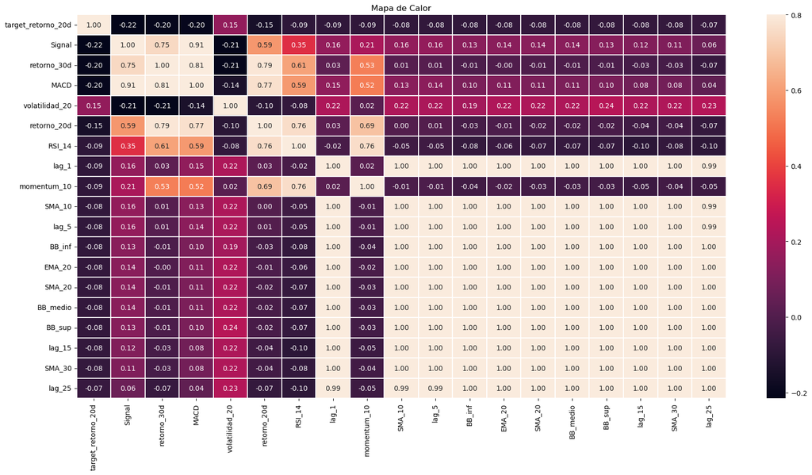

```python
# Se crea nuvamente la matriz ya con el data_f
mz_corr = data_f.corr()

# Crear mapa de calor
plt.subplots(figsize=(21,10))
sns.heatmap(mz_corr, annot=True, fmt=".2f", vmax=0.8, linewidths=0.2)
plt.title("Mapa de Calor")

## =================================
# Resultados
## =================================

#* Se generó una matriz de correlación para las 19 variables filtradas.
#* El mapa de calor permite identificar relaciones lineales fuertes o débiles entre predictores y con la variable objetivo target_retorno_20d.
#* Se observan grupos de variables altamente correlacionadas entre sí (por ejemplo, entre medias móviles y bandas de Bollinger).
```

## División de Datos – Definición de Features y Target

- Se ha definido el conjunto de predictores (X) eliminando la columna objetivo target_retorno_20d.
- La variable objetivo (y) corresponde a los retornos a 20 días, que será el valor que los modelos intentarán predecir.
- X contiene 18 variables independientes derivadas de indicadores técnicos y retardos, mientras que y es una serie unidimensional.

```python
## ===================
# Definir features y target:
## ===================

# Features
X = data_f.drop(columns=["target_retorno_20d"])

# Target
y = data_f["target_retorno_20d"]
```

```python
# Se carga libreria
from sklearn.model_selection import train_test_split

# Se crean las dos variables, una de train y otra de test, y se separa en entrenamiento y prueba con 20 y 80
X_train, X_test, y_train, y_test = train_test_split(X, y, test_size=0.2, random_state=42, shuffle=False)

# =====================
## Comentarios
# =====================
# test_size=0.2 : 80% entrenamiento, 20% prueba
# random_state=42 : asegura reproducibilidad.
# shuffle=False : muy importante en series temporales, porque no se debe mezclar el orden de los datos (si se pusiera shuffle=True, se perderia la secuencia cronológica).
```

#### Escalado de variables (features)

- Se aplicó RobustScaler sobre las variables predictoras (X) para los modelos lineales.
- Para los modelos no lineales (árboles, boosting, random forest, etc.), se conservaron los valores originales sin escalado.
- El target (y) no se modificó en ninguno de los casos.

```python
from sklearn.preprocessing import RobustScaler

# Inicializamos el escalador robusto (menos sensible a outliers)
scaler = RobustScaler()

# ---- Modelos lineales (necesitan escalado de X) ----
X_train_lin = scaler.fit_transform(X_train)
X_test_lin  = scaler.transform(X_test)

# ---- Modelos no lineales (se usan X originales sin escalar) ----
X_train_nonlin = X_train.copy()
X_test_nonlin  = X_test.copy()

# ---- El target (y) se mantiene igual en ambos casos ----
y_train_lin    = y_train.copy()
y_test_lin     = y_test.copy()
y_train_nonlin = y_train.copy()
y_test_nonlin  = y_test.copy()
```

## Creacion de modelos NO lineales

##### Capturan relaciones complejas entre las variables predictoras y la variable objetivo.

- No requieren escalado de datos (a diferencia de los modelos lineales).
- Son robustos frente a outliers y variables de distinta escala.

```python
## =========================
# Modelos NO LINEALES
## =========================
#* RandomForestRegressor: ensamble basado en múltiples árboles de decisión.
#* CatBoostRegressor: boosting eficiente con manejo nativo de variables categóricas.
#* XGBRegressor: implementación optimizada de gradient boosting.
#* LGBMRegressor: boosting de alta velocidad diseñado para grandes volúmenes de datos.

from sklearn.ensemble import RandomForestRegressor
from catboost import CatBoostRegressor
from xgboost import XGBRegressor
from lightgbm import LGBMRegressor
from sklearn.neural_network import MLPRegressor
```

```python
# ==========================================
# Modelo 1: Random Forest Regressor
# ==========================================

# Crear la instancia del modelo
rfr_model = RandomForestRegressor(
    n_estimators=200,       # número de árboles (default=100, aquí lo aumentamos para mayor estabilidad)
    max_depth=None,         # profundidad máxima (None = sin límite)
    random_state=42,        # semilla para reproducibilidad
    n_jobs=-1               # uso de todos los núcleos disponibles
)

# Entrenar el modelo con los datos de entrenamiento
rfr_model.fit(X_train_nonlin, y_train)

# Generar predicciones para train y test
y_train_pred_rfr = rfr_model.predict(X_train_nonlin)
y_test_pred_rfr  = rfr_model.predict(X_test_nonlin)
```

```python
# ==========================================
# Modelo 2: CatBoost Regressor
# ==========================================

from catboost import CatBoostRegressor

# Crear instancia del modelo
cat_model = CatBoostRegressor(
    iterations=500,       # número de iteraciones (default=1000)
    learning_rate=0.05,   # tasa de aprendizaje
    depth=8,              # profundidad de los árboles
    random_state=42,      # semilla para reproducibilidad
    verbose=0             # suprime la salida de logs
)

# Entrenar el modelo con los datos de entrenamiento
cat_model.fit(X_train_nonlin, y_train)

# Generar predicciones para train y test
y_train_pred_cat = cat_model.predict(X_train_nonlin)
y_test_pred_cat  = cat_model.predict(X_test_nonlin)
```

```python
# ==========================================
# Modelo 3: XGBoost Regressor
# ==========================================

from xgboost import XGBRegressor

# Crear instancia del modelo
xgb_model = XGBRegressor(
    n_estimators=500,      # número de árboles
    learning_rate=0.05,    # tasa de aprendizaje
    max_depth=6,           # profundidad máxima de los árboles
    subsample=0.8,         # muestreo de filas
    colsample_bytree=0.8,  # muestreo de columnas
    random_state=42,
    n_jobs=-1              # usar todos los núcleos disponibles
)

# Entrenar el modelo con los datos de entrenamiento
xgb_model.fit(X_train_nonlin, y_train)

# Generar predicciones para train y test
y_train_pred_xgb = xgb_model.predict(X_train_nonlin)
y_test_pred_xgb  = xgb_model.predict(X_test_nonlin)
```

```python
# ==========================================
# Modelo 4: LightGBM Regressor
# ==========================================

from lightgbm import LGBMRegressor

# Crear instancia del modelo con parámetros iniciales
lgbm_model = LGBMRegressor(
    n_estimators=1000,     # número de árboles
    learning_rate=0.05,    # tasa de aprendizaje
    max_depth=-1,          # sin límite de profundidad
    subsample=0.8,         # muestreo de filas
    colsample_bytree=0.8,  # muestreo de columnas
    random_state=42,
    n_jobs=-1              # usar todos los núcleos
)

# Entrenar el modelo
lgbm_model.fit(X_train_nonlin, y_train)

# Generar predicciones
y_train_pred_lgbm = lgbm_model.predict(X_train_nonlin)
y_test_pred_lgbm  = lgbm_model.predict(X_test_nonlin)
```

```
[LightGBM] [Info] Auto-choosing row-wise multi-threading, the overhead of testing was 0.000287 seconds.
You can set `force_row_wise=true` to remove the overhead.
And if memory is not enough, you can set `force_col_wise=true`.
[LightGBM] [Info] Total Bins 4590
[LightGBM] [Info] Number of data points in the train set: 2967, number of used features: 18
[LightGBM] [Info] Start training from score 0.013341
```

```python
## ============================
# Modelo 1: MLP Regressor
## ============================

mlp_model = MLPRegressor(
    hidden_layer_sizes=(100,),   # 1 capa oculta con 100 neuronas
    activation='relu',           # función de activación
    solver='adam',               # optimizador
    max_iter=1000,               # iteraciones máximas
    early_stopping=True,         # parada temprana para evitar overfitting
    validation_fraction=0.1,     # fracción del train reservada para validar
    random_state=42
)

# Entrenamiento (con X escaladas)
mlp_model.fit(X_train_lin, y_train_lin)

# Predicciones (también con X escaladas)
y_train_pred_mlp = mlp_model.predict(X_train_lin)
y_test_pred_mlp  = mlp_model.predict(X_test_lin)
```